# Neovascular Age-related Macular Degeneration Visual Outcomes

- Show All Code
- Hide All Code
- View Source

Author

Me

# Overview

**Aim:** to explore 12 year dataset of patients with treatment-naive neovascular age-related macular degeneration (AMD) who received intravitreal anti-VEGF therapy ([Fu et al](https://jamanetwork.com/journals/jamaophthalmology/fullarticle/2772986))

# Session 1

**Tip**

Pre-requisites:

- Install R and RStudio, as per [r4ds guidance](https://r4ds.hadley.nz/intro#prerequisites)
- Install the tidyverse set of packages (run install.packages(“tidyverse”) in the R console)

Topics:

- Starting a new R project
- R basics (data types, functions, variables)
- Scripts
- Importing tabular data from a csv to a data frame in R
- Selecting columns and filtering for rows using select() and filter() (from the dplyr package, tidyverse)
- Viewing and summarising data
- Boxplots with ggplot

Start your notebook by loading any required packages and importing raw data

```r
library(tidyverse)
library(dplyr) # sdf

amd <- read_csv("MEH_AMD_survivaloutcomes_database.csv")
```

## Explore data

Look at the first few rows using `head()` (in RStudio consider also using `View()` for an interactive table viewer)

```r
head(amd)
```

```
# A tibble: 6 × 16
   ...1     X gender ethnicity     age_group va_inj1 va_inj1_group date_inj1
  <dbl> <dbl> <chr>  <chr>         <chr>       <dbl> <chr>         <chr>
1     1     1 f      unknown/other 70-79          55 50-69         Pre-2013
2     2     2 f      unknown/other 70-79          55 50-69         Pre-2013
3     3     3 f      unknown/other 70-79          55 50-69         Pre-2013
4     4     4 f      unknown/other 70-79          55 50-69         Pre-2013
5     5     5 f      se_asian      70-79          75 >=70          Post-2013
6     6     6 f      se_asian      70-79          75 >=70          Post-2013
# ℹ 8 more variables: mean_inj_interval <dbl>, loaded <chr>, time <dbl>,
#   injnum <dbl>, injgiven <dbl>, va <dbl>, regimen <chr>, anon_id <chr>
```

Summarise with `summary()`

```r
summary(amd)
```

```
      ...1              X             gender           ethnicity
 Min.   :     1   Min.   :     1   Length:118255      Length:118255
 1st Qu.: 29564   1st Qu.: 29564   Class :character   Class :character
 Median : 59128   Median : 59128   Mode  :character   Mode  :character
 Mean   : 59128   Mean   : 59128
 3rd Qu.: 88692   3rd Qu.: 88692
 Max.   :118255   Max.   :118255

  age_group            va_inj1       va_inj1_group       date_inj1
 Length:118255      Min.   :  0.00   Length:118255      Length:118255
 Class :character   1st Qu.: 46.00   Class :character   Class :character
 Mode  :character   Median : 58.00   Mode  :character   Mode  :character
                    Mean   : 55.41
                    3rd Qu.: 69.00
                    Max.   :100.00

 mean_inj_interval    loaded               time            injnum
 Min.   :  14.0    Length:118255      Min.   :   0.0   Min.   : 1.000
 1st Qu.:  28.0    Class :character   1st Qu.: 147.0   1st Qu.: 3.000
 Median :  30.5    Mode  :character   Median : 447.0   Median : 7.000
 Mean   :  51.4                       Mean   : 633.9   Mean   : 8.883
 3rd Qu.:  45.5                       3rd Qu.: 930.0   3rd Qu.:12.000
 Max.   :1600.0                       Max.   :4042.0   Max.   :83.000
 NA's   :1807
    injgiven           va           regimen            anon_id
 Min.   :1       Min.   :  0.00   Length:118255      Length:118255
 1st Qu.:1       1st Qu.: 48.00   Class :character   Class :character
 Median :1       Median : 62.00   Mode  :character   Mode  :character
 Mean   :1       Mean   : 58.66
 3rd Qu.:1       3rd Qu.: 73.00
 Max.   :1       Max.   :100.00
 NA's   :38286   NA's   :1725
```

## Selecting columns and filtering rows

```r
amd_first_injection_vas <- amd |>
  select(anon_id,
         va,
         time,
         age_group) |>
  filter(time == 0)
```

> - N rows in full dataset: 118255
> - N rows in filtered dataset: 7802

## Plots

Box and whisker plots

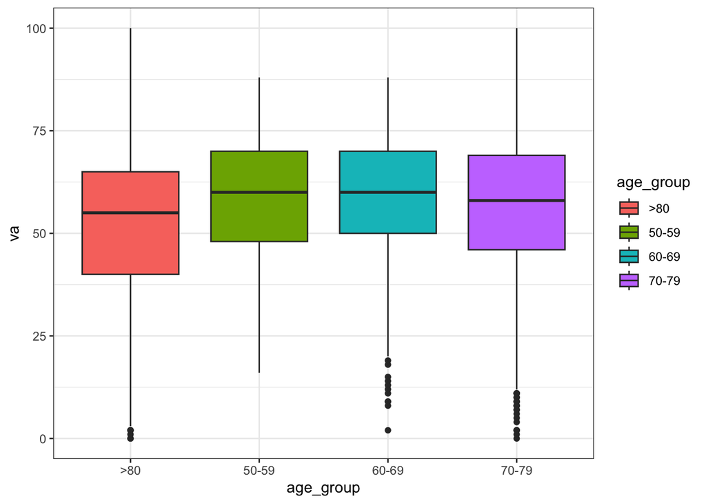

```r
amd_first_injection_vas |>
    ggplot(aes(x = age_group, y = va)) +
    geom_boxplot(aes(fill = age_group)) +
    theme_bw()
```

Histogram

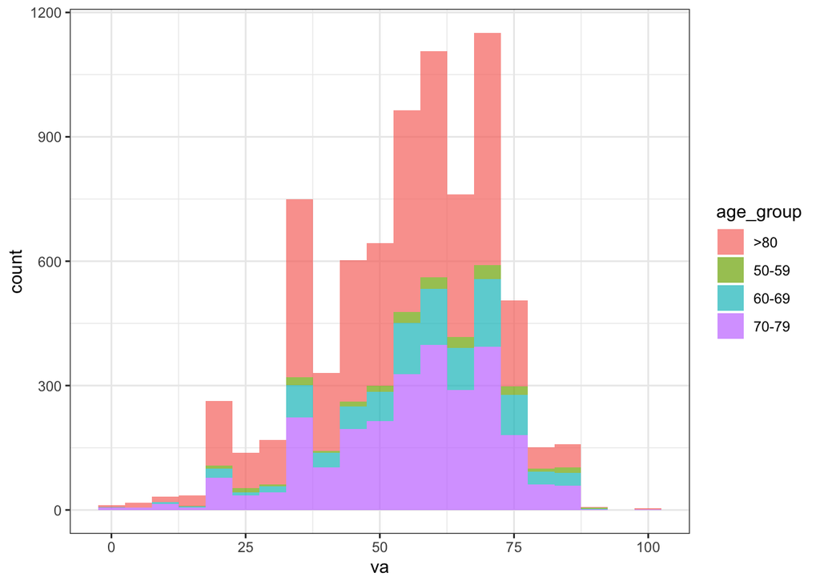

```r
amd_first_injection_vas |>
    ggplot(aes(x = va)) +
    geom_histogram(aes(fill = age_group), alpha = 0.7, binwidth = 5) +
    theme_bw()
```

# Session 2

```r
# Note: while we call library() here, in general you should always put *all* library() calls and variables at the start of your script/notebook
library(gtsummary)
library(flextable)
```

**Tip**

Topics:

- More data wrangling
- Creating a manuscript ‘Table 1’
- Linear regression

## More wrangling - VA at month 12

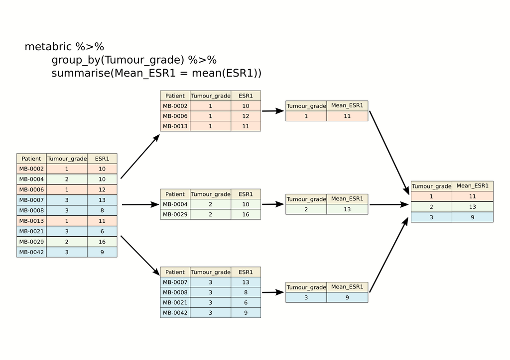

A common workflow is to summarise data by groups e.g. N eyes by treatment regimen:

```r
amd |>
  group_by(regimen) |>
  # `n_distinct(anon_id)` ensures we get number of eyes by treatment regimen, rather than number of observations which would be `summarise(n_observations = n())` or `summarise(n_observations = length(anon_id))`
  summarise(n_ids = n_distinct(anon_id))
```

```
# A tibble: 2 × 2
  regimen          n_ids
  <chr>            <int>
1 Aflibercept only  3951
2 Ranabizumab only  3851
```

```r
amd_12_month <- amd |>
  # first group by eye
  group_by(anon_id) |>

  # create a new column with time (in days) from 1 year. We use `abs()` to convert negative values to positive
  mutate(time_from_12_months = abs(365 - time)) |>

  # take one row of data per eye, the one closest to 1 year
  slice_min(time_from_12_months, with_ties = FALSE, na_rm = TRUE) |>

  # remember to ungroup
  ungroup() |>

  # VA must be within one month of 1 year to be included
  filter(time_from_12_months < 30) |>

  # rename va column to indicate this is now VA at 12 month only
  rename(va_12m = va)
```

Baseline vision is already recorded under `va_inj1`. If it wasn’t then we could have achieved the same result using a [join](https://r4ds.hadley.nz/joins.html), instead of `slice_min()`:

```r
# data frame with just (i) ID and (ii) vision at baseline columns (for demonstration)
amd_0_month <- amd_first_injection_vas |>
  select(anon_id,
         va_0m = va)

amd_12_month |>
  # remove baseline vision column for demonstration purposes
  select(-va_inj1) |>

  # join data frame with baseline vision
  left_join(amd_0_month,
            by = "anon_id") |>

  # select columns (for demonstration)
  select(anon_id,
         starts_with("va_"))
```

```
# A tibble: 4,252 × 4
   anon_id                                            va_inj1_group va_12m va_0m
   <chr>                                              <chr>          <dbl> <dbl>
 1 00081b40ab38fa7bada9c48fc3eed2e4c1e1741548bfd4039… 36-49             35    46
 2 0018ee619b6a77d07e2466e55ca84d9d20041ede600858580… >=70              61    70
 3 0024430dd21ec7d2bf85b4722f629852132cbc29de700c0fe… 50-69             77    65
 4 0036e526db61d937c27b6fe3977cae8ac1ef021ca5874584c… 50-69             20    50
 5 0059f04c0892d8148063b2259161d74db885e30531206ba8c… >=70              65    83
 6 006ef90502f583eb8d93753e536e681da423c309ef1d1c618… >=70              70    73
 7 008843ff08f8321eb9bc435b204696880c2aa7fce3528c1c7… 50-69             69    60
 8 008d118de9f1ac67424401d079ca0904741906a9ac2978820… >=70              77    80
 9 00b8ae6605b5854a429cb9cb1cb51276999f582f5d6f84c32… 50-69             74    68
10 00e95e77dcb22ff50775c69a78028c8ac0f18cdb9975fefe3… 36-49             65    48
# ℹ 4,242 more rows
```

## Create table 1

By hand:

```r
amd_12_month |>
  summarise(median_baseline_va = median(va_inj1, na.rm = TRUE),
            median_12month_va = median(va_12m, na.rm = TRUE))
```

```
# A tibble: 1 × 2
  median_baseline_va median_12month_va
               <dbl>             <dbl>
1                 58                65
```

Using `gtsummary::tbl_summary()`:

```r
amd_12_month |>
  select(gender,
         age_group,
         ethnicity,
         va_inj1,
         va_12m,
         date_inj1,
         regimen) |>
  tbl_summary()
```

| **Characteristic** | **N = 4,252**<sup>1</sup> |
| --- | --- |
| gender |  |
| f | 2,587 (61%) |
| m | 1,665 (39%) |
| age_group |  |
| >80 | 2,109 (50%) |
| 50-59 | 123 (2.9%) |
| 60-69 | 558 (13%) |
| 70-79 | 1,462 (34%) |
| ethnicity |  |
| afrocarribean | 84 (2.0%) |
| caucasian | 2,651 (62%) |
| mixed | 15 (0.4%) |
| se_asian | 367 (8.6%) |
| unknown/other | 1,135 (27%) |
| va_inj1 | 58 (46, 69) |
| va_12m | 65 (50, 73) |
| Unknown | 80 |
| date_inj1 |  |
| Post-2013 | 2,622 (62%) |
| Pre-2013 | 1,630 (38%) |
| regimen |  |
| Aflibercept only | 2,419 (57%) |
| Ranabizumab only | 1,833 (43%) |

<sup>1</sup> n (%); Median (Q1, Q3)

…and by date of baseline injection, with group comparison:

```r
amd_12_month |>
  select(gender,
         age_group,
         ethnicity,
         va_inj1,
         va_12m,
         date_inj1,
         regimen) |>
  tbl_summary(by = "date_inj1") |>
  add_p() |>
  bold_p()
```

| **Characteristic** | **Post-2013** N = 2,622<sup>1</sup> | **Pre-2013** N = 1,630<sup>1</sup> | **p-value**<sup>2</sup> |
| --- | --- | --- | --- |
| gender |  |  | <0.001 |
| f | 1,537 (59%) | 1,050 (64%) |  |
| m | 1,085 (41%) | 580 (36%) |  |
| age_group |  |  | 0.2 |
| >80 | 1,323 (50%) | 786 (48%) |  |
| 50-59 | 72 (2.7%) | 51 (3.1%) |  |
| 60-69 | 354 (14%) | 204 (13%) |  |
| 70-79 | 873 (33%) | 589 (36%) |  |
| ethnicity |  |  | <0.001 |
| afrocarribean | 50 (1.9%) | 34 (2.1%) |  |
| caucasian | 1,468 (56%) | 1,183 (73%) |  |
| mixed | 8 (0.3%) | 7 (0.4%) |  |
| se_asian | 238 (9.1%) | 129 (7.9%) |  |
| unknown/other | 858 (33%) | 277 (17%) |  |
| va_inj1 | 59 (46, 69) | 55 (46, 65) | 0.020 |
| va_12m | 65 (51, 75) | 62 (50, 73) | <0.001 |
| Unknown | 74 | 6 |  |
| regimen |  |  | <0.001 |
| Aflibercept only | 2,419 (92%) | 0 (0%) |  |
| Ranabizumab only | 203 (7.7%) | 1,630 (100%) |  |

<sup>1</sup> n (%); Median (Q1, Q3)  
<sup>2</sup> Pearson’s Chi-squared test; Wilcoxon rank sum test

## Linear regression

Is baseline vision associated with vision at 12 months?

Visualise:

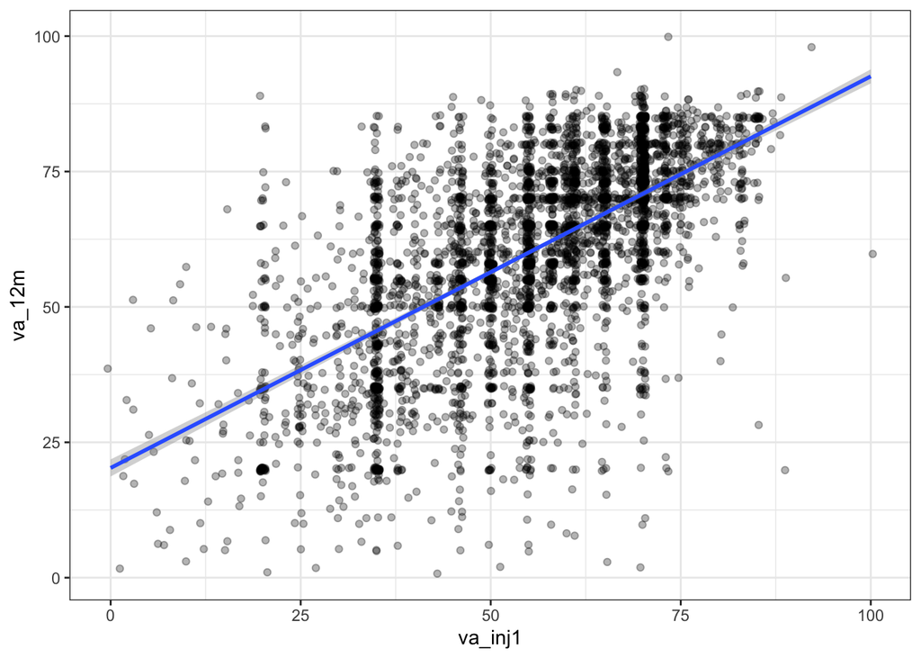

```r
amd_12_month |>
  ggplot(aes(x = va_inj1,
             y = va_12m)) +
  geom_point(alpha = 0.3,
             position = "jitter") +
  geom_smooth(method = "lm") +
  theme_bw()
```

Linear regression model with one predictor (baseline VA) for VA at 12 months (outcome), summarised using `summary()`:

```r
lm_12m_va <- lm(va_12m ~ va_inj1, data = amd_12_month)
summary(lm_12m_va)
```

```
Call:
lm(formula = va_12m ~ va_inj1, data = amd_12_month)

Residuals:
    Min      1Q  Median      3Q     Max
-68.878  -7.525   1.475   8.983  54.274

Coefficients:
            Estimate Std. Error t value Pr(>|t|)
(Intercept) 20.26517    0.80469   25.18   <2e-16 ***
va_inj1      0.72304    0.01399   51.69   <2e-16 ***
---
Signif. codes:  0 '***' 0.001 '**' 0.01 '*' 0.05 '.' 0.1 ' ' 1

Residual standard error: 14 on 4170 degrees of freedom
  (80 observations deleted due to missingness)
Multiple R-squared:  0.3905,    Adjusted R-squared:  0.3903
F-statistic:  2671 on 1 and 4170 DF,  p-value: < 2.2e-16
```

Can also summarise using `tbl_regression()`:

```r
tbl_regression(lm_12m_va) |>
  bold_p()
```

| **Characteristic** | **Beta** | **95% CI**<sup>1</sup> | **p-value** |
| --- | --- | --- | --- |
| va_inj1 | 0.72 | 0.70, 0.75 | <0.001 |

<sup>1</sup> CI = Confidence Interval